# Las trabajadoras de servicio doméstico en Argentina

1er trimestre de 2020

Natsumi Shokida para #EcoFemiData, equipo de dato de EcoFeminita - Septiembre de 2020

## Secciones

### Introducción

#### Introducción

El presente informe tiene como objetivo visibilizar las condiciones de trabajo, ingresos, y principales características de las trabajadoras que prestan servicio doméstico en hogares particulares. Para ello se presentan diversos indicadores, cuadros y gráficos de elaboración propia respondiendo a preguntas como ¿Cuántas personas se dedican a brindar servicios domésticos en hogares?, ¿Qué tan feminizado se encuentra el sector?, ¿Tienen jornadas completas de trabajo?, ¿Cuánto cobran por mes?¿Y por hora?, ¿Qué tanto se respetan sus derechos laborales?, ¿También son quienes realizan las tareas domésticas en su propio hogar?, ¿Son el principal sostén económico de sus hogares?, y también se realiza una comparación con otras ramas de ocupaciones.  
Para realizar los cálculos se utilizan bases de datos publicadas por la Encuesta Permanente de Hogares del INDEC, en este caso referidas al 1er trimestre de 2020. Esta encuesta releva características demográficas, sociales, económicas, con especial atención a las formas de participación en el mercado laboral, entre hogares y personas de 31 aglomerados urbanos (pensémoslo como las grandes ciudades del país). El documento se realizó utilizando el lenguaje de programación R, y para les curioses todo el código se encuentra disponible para su descarga.  
Este reporte puede volverse un poco técnico por momentos, pero seguramente desde [EcoFeminita](http://economiafeminita.com/) realicemos también otras notas de carácter divulgatorio. Obviamente, estás invitade a utilizar estos datos en notas, reflexiones, trabajos, infografías, etc[^1]. Además, si te gusta lo que hacemos podés apoyarnos potenciando nuestros proyectos, haciéndote socie del [#ClubEcofeminita o realizando una donación](https://donaronline.org/economia-femini-s-ta/club-ecofeminita).

### Trabajadoras de servicio doméstico

#### Trabajadoras de servicio doméstico

El interés por analizar distintas características de las trabajadoras de servicio doméstico radica principalmente en la magnitud que dicha ocupación presenta, en su estrecho vínculo con la división sexual del trabajo y la feminización de este sector y, como veremos luego, por las particularmente diferenciadas condiciones, acceso a derechos y bajos ingresos que perciben a cambio de su trabajo. Entre las grandes ciudades del país, pueden contarse **casi 900 mil personas que componen al sector**. A su vez, la tasa de feminidad del sector es del 98,5%. Es decir que **casi en su totalidad se trata de trabajadoras mujeres**. Es por esto que, a lo largo de todo el informe, utilizaremos pronombres femeninos a la hora de generalizar, aunque muchas veces estemos hablando del conjunto de les trabajadores que se dedican a esta actividad. A su vez, cabe destacar que el ejercicio debe ser realizado en términos cis-binarios por falta de información respecto de las identidades trans-travesti en las estadísticas oficiales.  
Las trabajadoras que realizan tareas domésticas y de cuidado en hogares particulares representan un 16,4% dentro del total de ocupadas mujeres. Esto significa que **una de cada 6 ocupadas en Argentina trabaja en este sector de la economía**. Al mismo tiempo, estas trabajadoras representan un 21,6% dentro del total de ocupadas-asalariadas. O sea que dentro de las mujeres que trabajan en relación de dependencia, alrededor de 1 de cada 5 tiene como ocupación principal el trabajo en hogares particulares. Como veremos más adelante, se trata de **la ocupación más popular entre las mujeres**.

**Cantidad de personas que se dedican al servicio doméstico**

| 888.555 |
| --- |

**Porcentaje de mujeres y de varones en el sector**

| Sexo | Porcentaje |
| --- | --- |
| Mujeres | 98,5 |
| Varones | 1,5 |

**Porcentaje de la ocupación dentro de las ocupadas mujeres**

| ¿Se dedica al servicio doméstico? | Porcentaje |
| --- | --- |
| No | 83,6 |
| Sí | 16,4 |

**Porcentaje de la ocupación dentro de las asalariadas mujeres**

| ¿Se dedica al servicio doméstico? | Porcentaje |
| --- | --- |
| No | 78,4 |
| Sí | 21,6 |

### Características

#### Algunas características de las trabajadoras de servicio doméstico

En esta sección se presentan algunas métricas respecto a la distribución etaria, el lugar de nacimiento y características educativas de las trabajadoras del sector de servicio doméstico. Se destacan la sobrerrepresentación de migrantes en el sector, y las dificultades de sostener estudio y trabajo en paralelo si se trabaja en esta rama ocupacional.

##### Edad

Mientras que un 45,5% de estas trabajadoras tienen entre 30 y 49 años, un 31% tiene entre 50 y 64 años. Por su parte, hay un 6,7% que continúa trabajando a pesar de haber superar los 65 años, y un 16,8% está compuesto por jóvenes que no llegan a los 30 años. Este último grupo está compuesto por casi 150 mil jóvenes.

**Composicion por edad de las trabajadoras del servicio doméstico**

| Edad | Cantidad | Porcentaje |
| --- | --- | --- |
| de 14 a 29 años | 149.556 | 16,8 |
| de 30 a 49 años | 403.871 | 45,5 |
| de 50 a 64 años | 275.414 | 31,0 |
| 65 años y más | 59.714 | 6,7 |

##### Lugar de nacimiento

Considerando a la población en general, un 12,3% se encuentra viviendo en una provincia distinta a la que tiene como lugar de nacimiento, y un 3,5% proviene de un país limítrofe. Por su parte, **en el caso de las trabajadoras de servicio doméstico**, más del 20% ha migrado de provincia y más del 10% proviene de un país limítrofe, es decir que **las personas migrantes se encuentran sobrerrepresentadas en dicho sector de la economía**. Puede observarse entonces que la ocupación está estrechamente relacionada con los fenómenos migratorios.

**Lugar de nacimiento de las trabajadoras de servicio doméstico y del total de la población**

| ¿Dónde nació? | Trabajadoras de Servicio Doméstico Cantidad | Trabajadoras de Servicio Doméstico Porcentaje | Población general Cantidad | Población general Porcentaje |
| --- | --- | --- | --- | --- |
| En esta localidad | 522.506 | 58,8 | 21.848.980 | 76,6 |
| En otra localidad de esta provincia | 74.043 | 8,3 | 1.704.081 | 6,0 |
| En otra provincia | 183.228 | 20,6 | 3.504.242 | 12,3 |
| En un país limítrofe | 90.462 | 10,2 | 985.845 | 3,5 |

*Nota: Las estimaciones correspondientes a aquellas personas que han nacido en otro país (no limítrofe) y aquellas que NS/NR la pregunta, no cuentan con suficientes casos muestrales como para garantizar significatividad del dato, por lo que se ha retirado del cuadro las categorías.*

##### Educación

Más de la mitad de las trabajadoras del sector finalizó el nivel primario de escolaridad, a lo que se suma un 34,4% que cuenta también con el nivel secundario, en tanto un 8,9% no posee instrucción formal.

**Composicion por nivel educativo de las trabajadoras del servicio doméstico**

| Nivel educativo | Cantidad | Porcentaje |
| --- | --- | --- |
| Sin Instrucción | 79.348 | 8,9 |
| Primaria | 468.876 | 52,8 |
| Secundaria | 305.715 | 34,4 |

*Nota: La estimación correspondiente a aquellas que han finalizado un nivel superior de formación no cuenta con suficientes casos muestrales como para garantizar significatividad del dato, por lo que se ha retirado del cuadro la categoría.*

**Las jóvenes y su formación educativa**

Entre **las más jóvenes del sector, aquellas que tienen entre 14 y 29 años**, alrededor del 70% no asiste actualmente a un establecimiento educativo aunque asistió en el pasado, mientras que **3 de cada 10 estudian al mismo tiempo que se desempeñan como trabajadoras de servicio doméstico**. Este indicador se ubica casi 6 puntos por debajo de la correspondiente para aquellas jóvenes que no se dedican a esta tarea en particular. En promedio, **parece más difícil sostener estudio y trabajo en paralelo si se trabaja en el sector que estamos analizando**.

**Mujeres jóvenes del servicio doméstico por asistencia a establecimiento educativo**

| ¿Asiste a un establecimiento educativo? | Cantidad | Porcentaje |
| --- | --- | --- |
| Asiste actualmente | 43.507 | 29,6 |
| No asiste, pero asistió en el pasado | 103.530 | 70,4 |

*Nota: La estimación correspondiente a aquellas que nunca asistieron a un establecimiento educativo no cuenta con suficientes casos muestrales como para garantizar significatividad del dato, por lo que se ha retirado del cuadro la categoría.*

**Ocupadas jóvenes según si se dedican al servicio doméstico y su respectiva tasa de asistencia a un establecimiento educativo**

| ¿Se dedica al servicio doméstico? | Tasa de asistencia a est. educativo |
| --- | --- |
| No | 35,4 |
| Sí | 29,6 |

*Nota: La estimación correspondiente a aquellas que nunca asistieron a un establecimiento educativo no cuenta con suficientes casos muestrales como para garantizar significatividad del dato, por lo que se ha retirado del cuadro la categoría.*

### Intensidad del trabajo

#### Intensidad del trabajo de las trabajadoras de servicio doméstico

En relación a la cantidad de horas que trabajan semanalmente las empleadas domésticas, un 53,8% son ocupadas “plenas”, es decir que trabajan entre 35 y 45 horas semanales, o están conformes con la cantidad de horas que trabajan. Al mismo tiempo **un 31,6% se encuentra sub-ocupada**, trabaja menos de 35 horas semanales por causas involuntarias, estando dispuestas a trabajar más horas. Por su parte, **un 9,1% está sobre-ocupada**, trabaja más de 45 horas por semana.  
En cuanto a la cantidad de hogares en que se desempeñan, un 76,2% trabaja en una sola casa, por lo que al mismo tiempo casi un 25% de ellas trabaja en más de una vivienda. **Mientras que las que son contratadas por un sólo hogar trabajan cerca de 24 horas semanales (jornada part-time), aquellas que trabajan en más de una casa trabajan en promedio menos de 20 horas por semana en la ocupación principal, acercándose a las 25 horas semanales con las ocupaciones secundarias**.

**Trabajadoras de servicio doméstico según intensidad del trabajo**

| Intensidad | Cantidad | Porcentaje |
| --- | --- | --- |
| Ocupadas plenas | 477.707 | 53,8 |
| Sobreocupadas | 80.669 | 9,1 |
| Subocupadas por insuficiencia horaria | 280.349 | 31,6 |

*Nota: La estimación correspondiente a aquellas que no trabajaron en la semana de referencia de la encuesta no cuenta con suficientes casos muestrales como para garantizar significatividad del dato, por lo que se ha retirado del cuadro la categoría.*

**Trabajadoras del servicio doméstico según la cantidad de hogares en los que trabajan**

| Cantidad de hogares en que trabaja | Cantidad | Porcentaje | hs/sem en ocup. princ. | hs/sem con ocup. secund. |
| --- | --- | --- | --- | --- |
| 1 | 639.075 | 76,2 | 23,5 | 23,9 |
| 2 | 118.198 | 14,1 | 18,5 | 25,7 |
| 3 o más | 81.452 | 9,7 | 14,0 | 25,1 |

### Derechos laborales

#### Derechos laborales de las trabajadoras de servicio doméstico

Dentro del conjunto de asalariades, un 35,8% no se encuentra registrade en la seguridad social. Esta tasa asciende al 37,5% cuando hablamos de las asalariadas mujeres, pero también puede observarse que la problemática es particularmente incisiva entre las trabajadoras domésticas: **un 74,5% de ellas no percibe descuento jubilatorio. Asociado a esto, un 68,8% de estas trabajadoras no cuenta con vacaciones pagas, un 68,1% no percibe aguinaldos, un 70,9% no percibe el pago en caso de enfermedad, y un 73,2% no cuenta con cobertura de salud mediante obra social**.

**En ese trabajo tiene…**

| Indicador | Sí | No |
| --- | --- | --- |
| ¿Tiene descuento jubilatorio? | 25,5 | 74,5 |
| ¿Tiene vacaciones pagas? | 30,9 | 68,8 |
| ¿Tiene aguinaldo? | 31,7 | 68,1 |
| ¿Tiene días pagos por enfermedad? | 28,8 | 70,9 |
| ¿Tiene obra social? | 26,5 | 73,2 |

### Ingresos

#### Ingresos de las trabajadoras de servicio doméstico

Las trabajadoras del sector perciben ingresos que, en promedio, rondan los $9.300 pesos mensuales por su ocupación principal. Al mismo tiempo, un 50% de ellas cobra menos de $8.000 por mes por dicho trabajo. Esto equivale a que en promedio cobran unos $120 por hora, y el 50% cobra menos de $110 por hora. En el primer cuadro también pueden apreciarse los ingresos mensuales totales de fuente laboral (incluyendo ingresos de ocupaciones secundarias), los totales individuales (incluyendo ingresos que no provienen de una fuente laboral), los ingresos totales familiares que tienen en promedio los hogares de estas trabajadoras, y el ingreso per cápita familiar de estos mismos hogares.  
En el segundo cuadro puede apreciarse que hay una amplia diferencia entre los ingresos que perciben en promedio las trabajadoras que se encuentran registradas respecto de aquellas que no, tanto en términos mensuales como por hora trabajada. Además, aquellas que tienen descuento jubilatorio trabajan más horas en su ocupación principal respecto que aquellas que no.  
Si ordenamos al total de las personas ocupadas de acuerdo al nivel de ingresos que perciben por su ocupación principal, y las agrupamos en 10 grupos de igual tamaño, obtenemos los denominados deciles de ingreso. En el gráfico se muestra claramente que aquellas personas que trabajan en el sector de servicio doméstico se encuentran concentradas en los deciles de menores ingresos.  
Ojo! Debe tenerse en cuenta que todos los montos están expresados en pesos del 1er trimestre de 2020.

**Promedio y mediana de los ingresos de las trabajadoras de servicio doméstico y sus familias**

| Ingresos | Ingreso promedio | 50% cobra menos de |
| --- | --- | --- |
| Mensuales, de la ocupación principal | $9.345,44 | $8.000,00 |
| Por hora, de la ocupación principal | $120,61 | $110,45 |
| Mensuales, total de fuente laboral | $11.789,33 | $9.600,00 |
| Mensuales, ingreso total individual | $17.106,63 | $14.000,00 |
| Mensuales, ingreso total familiar | $46.425,66 | $38.000,00 |
| Mensuales, ingreso per cápita familiar | $14.022,18 | $11.333,33 |

**Trabajadoras de servicio doméstico según si tienen descuento jubilatorio, sus ingresos y horas de trabajo promedio**

| ¿Tiene descuento jubilatorio? | Ingreso mensual promedio | Ingreso por hora promedio | hs/sem en ocup. princ. |
| --- | --- | --- | --- |
| Sí | $13.722,51 | $127,38 | 28,3 |
| No | $7.923,02 | $118,41 | 19,8 |

**Trabajadoras de servicio domśtico según deciles de ingreso de la ocupación principal**

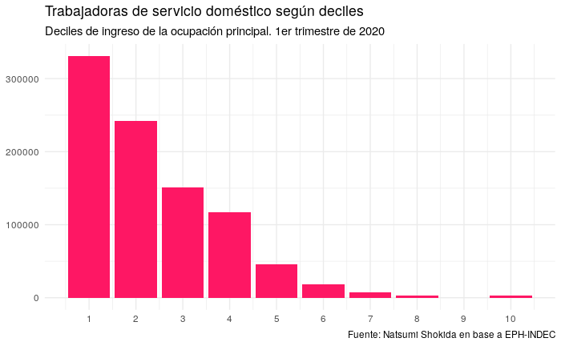

### Hogares

#### Algunas características referidas a los hogares de las trabajadoras de servicio doméstico

Si esta vez ordenamos al total de las personas de acuerdo a sus ingresos per cápita familiares (aquellos que surgen de dividir el total de ingresos de la familia por la cantidad de miembros de la misma), de menor a mayor, y las agrupamos en 10 grupos de igual tamaño, obtenemos otra escala de deciles. En este caso también se puede apreciar que **las trabajadoras de servicio doméstico se concentran en los primeros deciles. Cabe destacar que los primeros tres deciles de esta escala suelen estar altamente relacionados con la situación de pobreza de los hogares** (tomando como referencia la metodología oficial de cálculo de la misma).  
Al mismo tiempo, mientras que **un 54,6% no es el primer sostén económico del hogar, un 45,4% sí lo es**. En ambos casos, la mayoría de ellas realizan las tareas domésticas en su hogar. Esto es así porque **un 76,7% de quienes trabajan de forma remunerada realizando trabajo doméstico también están a cargo de la realización de este trabajo en sus hogares** de manera no-asalariada, y por tanto no remunerada.

**Trabajadoras de servicio domśtico según deciles de ingreso per cápita familiar**

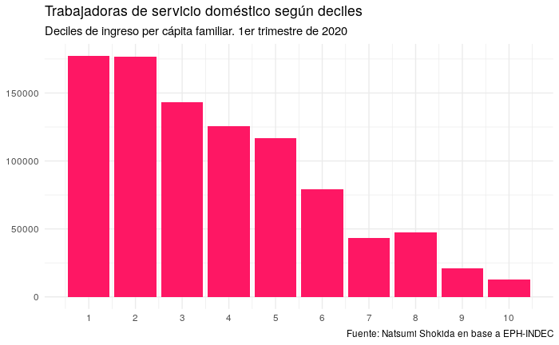

**Trabajadoras de servicio doméstico según si perciben el ingreso principal de su grupo familiar y si son quienes realizan las tareas domésticas en su hogar**

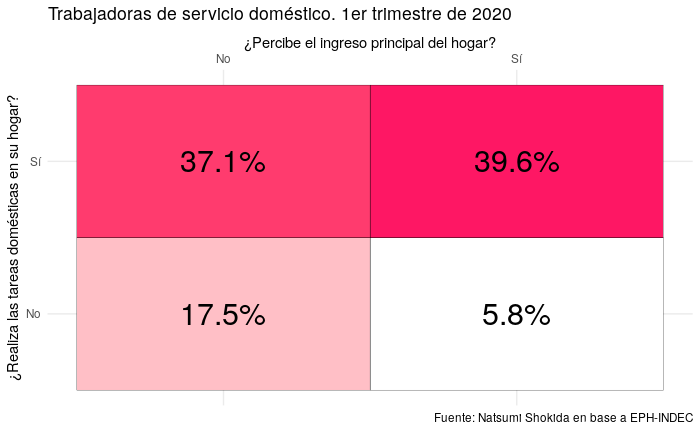

### Comparación con otras ramas de la ocupación

#### Comparación con otras ramas de la ocupación

Es útil contextualizar muchos de los indicadores presentados realizando una comparación con otras ramas de ocupación. En esta sección se presenta una serie de gráficos que permiten realizar este ejercicio. En todos los casos se considera a la población asalariada, es decir a las personas que se desempeñan en el mercado laboral con una relación de dependencia, y teniendo en cuenta las características de la ocupación principal de estas personas.  
Se destaca que **el sector de servicio doméstico es uno de los más importantes del mercado laboral. También se trata de la rama más feminizada, es la que más proporción ocupa dentro de las trabajadoras mujeres y la menos popular entre los varones. También es la rama que presenta la tasa de no-registro más alta, y los ingresos promedios más bajos, tanto de bolsillo como por hora trabajada**.

##### Cantidad de trabajadores

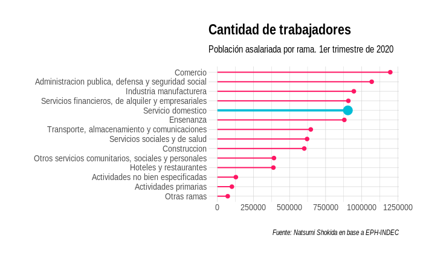

##### Tasa de feminización

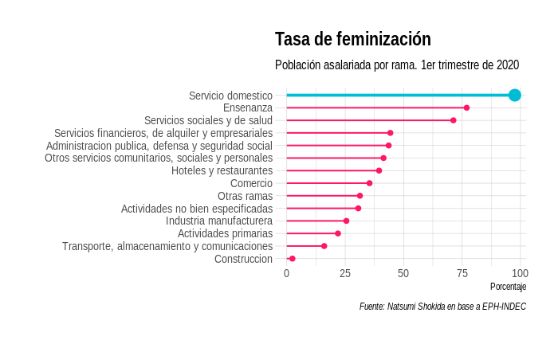

##### Proporción entre las asalariadas mujeres

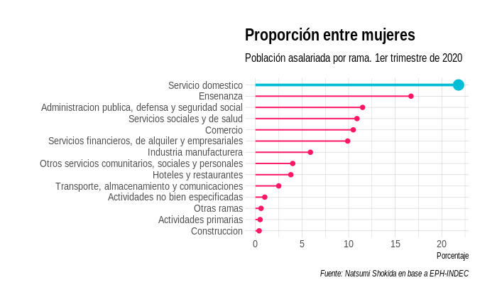

##### Proporción entre los asalariados varones

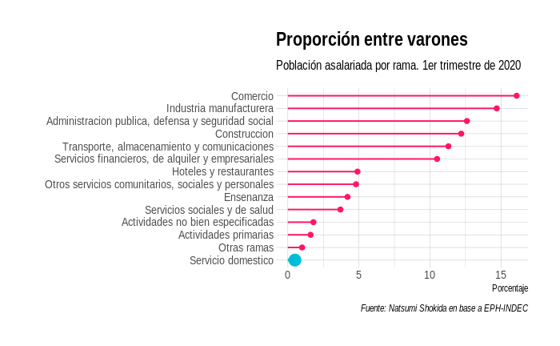

##### Tasa de no registro de la relación laboral

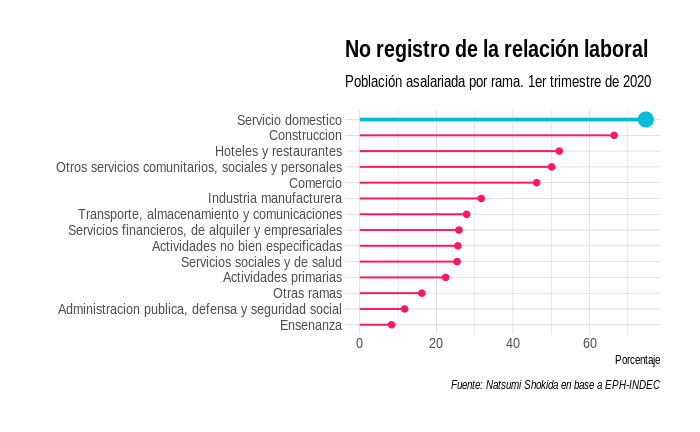

##### Ingresos mensuales promedio

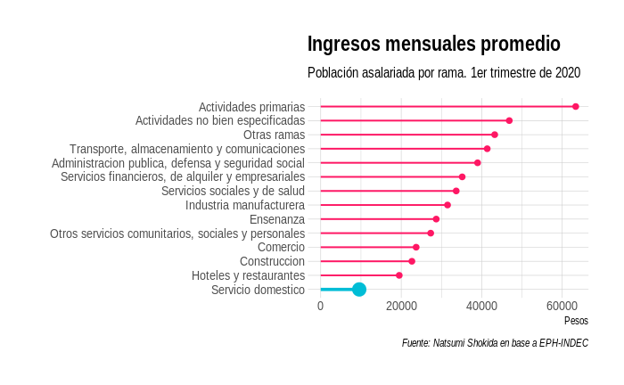

##### Ingresos por hora promedio

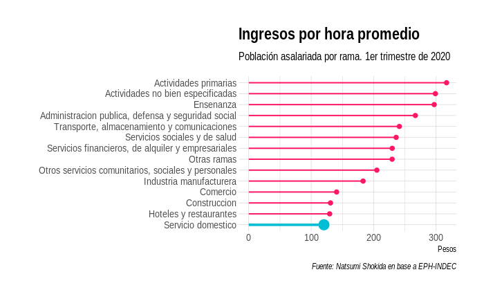